# #Regression and model validation

### Fitting the regression model

The third and fourth tasks are to fit the regression model and explain it.

Linear regression is an approach for modeling the relationship between a dependent variable $y$ and one or more explanatory variables $X$.

I chose attitude, deep and strategic learning variables as explanatory variables for the dependent *points* variable. In this case the model is of a form:

$points = x_0 + x_1*attitude + x_2 * deep + x_3* stra + e,$ here $e$ is an un-observable random variable which is assumed to add noise to the observations.

In the below code linear model is fitted for estimating the coefficients $x_0, x_1, x_2$.

```r
# Fitting a linear model
my_model <- lm(points ~ attitude + deep + stra, data = learning2014)

# Printing out a summary of the model
summary(my_model)
```

```
##
## Call:
## lm(formula = points ~ attitude + deep + stra, data = learning2014)
##
## Residuals:
##      Min       1Q   Median       3Q      Max
## -17.5239  -3.4276   0.5474   3.8220  11.5112
##
## Coefficients:
##             Estimate Std. Error t value Pr(>|t|)
## (Intercept)  11.3915     3.4077   3.343  0.00103 **
## attitude      3.5254     0.5683   6.203 4.44e-09 ***
## deep         -0.7492     0.7507  -0.998  0.31974
## stra          0.9621     0.5367   1.793  0.07489 .
## ---
## Signif. codes:  0 '***' 0.001 '**' 0.01 '*' 0.05 '.' 0.1 ' ' 1
##
## Residual standard error: 5.289 on 162 degrees of freedom
## Multiple R-squared:  0.2097, Adjusted R-squared:  0.195
## F-statistic: 14.33 on 3 and 162 DF,  p-value: 2.521e-08
```

When the p-value is less than the chosen significance level, we can reject the null hypothesis that the coefficient of model’s variable is equal to 0. It means that the variable adds significant benefit to the model. In this model above, only *intercept* and *attitude* has p-values smaller than significance level 0.05. Therefore, I have removed *deep* and *stra* variables from the model and build the second model including only *attitude* variable, which has significant relationship with the target variable.

```r
# Fitting second linear model
my_model2 <- lm(points ~ attitude, data = learning2014)

# Printing out a summary of the model
summary(my_model2)
```

```
##
## Call:
## lm(formula = points ~ attitude, data = learning2014)
##
## Residuals:
##      Min       1Q   Median       3Q      Max
## -16.9763  -3.2119   0.4339   4.1534  10.6645
##
## Coefficients:
##             Estimate Std. Error t value Pr(>|t|)
## (Intercept)  11.6372     1.8303   6.358 1.95e-09 ***
## attitude      3.5255     0.5674   6.214 4.12e-09 ***
## ---
## Signif. codes:  0 '***' 0.001 '**' 0.01 '*' 0.05 '.' 0.1 ' ' 1
##
## Residual standard error: 5.32 on 164 degrees of freedom
## Multiple R-squared:  0.1906, Adjusted R-squared:  0.1856
## F-statistic: 38.61 on 1 and 164 DF,  p-value: 4.119e-09
```

Below is a code for a fitted line plot which shows a scatterplot of the data with a regression line representing the regression equation.

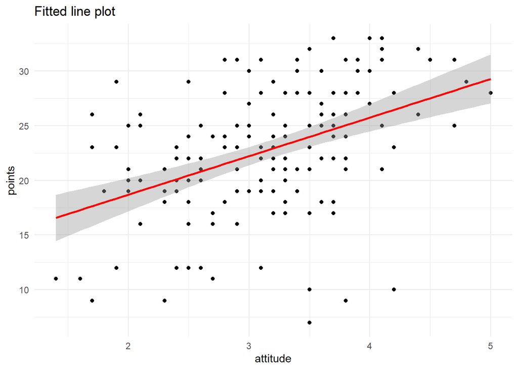

```r
#Plotting the regression line by the model
ggplot(learning2014, aes(x = attitude, y = points)) +
  geom_point() +
  stat_smooth(method = "lm", col = "red") +ggtitle("Fitted line plot") +theme_minimal()
```

The resulting model has such form

$points = 11.64 + 3.53*attitude$.

The attitude coefficient in the regression equation is 3.53. This coefficient represents the mean increase of exam points for every additional unit in attitude measurement. That is, if the *attitude* value increases by 1, then exam points increase by 3.53.

R-squared is a measure of how good is the fit of linear regression models. It indicates the percentage of the variance in the dependent variable that the independent variables explain collectively. In this case independent variable is only *attitude* and based on R-squared value of summary table, it explains 19% of variance in the *points* variable. In the case when *deep* and *stra* variables are included, the value of R-squared is slightly bigger and shows that 21% of variability in *points* variable is explained.